# STA 9750 Mini-Project #02: How Do You Do ‘You Do You’?

Author

Raúl J. Solá Navarro

Published

April 3, 2026

## Introduction

The American Time Use Survey (ATUS), a joint initiative of the US Bureau of Labor Statistics and the US Census Bureau, provides a look into how Americans allocate their time. In this report, we analyze over two decades of ATUS microdata (2003–2024) looking for patterns regarding how different demographic groups spend their days. We then apply these findings to design time-use profiles for a new time-tracking app targeting specific user demographics.

## Data Acquisition

**View R Code**

```r
library(tidyverse)
library(glue)
library(readxl)
library(httr2)
library(gt)
library(scales)
library(ggrepel)
library(ggbump)
library(ggforce)
```

**View R Code**

```r
load_atus_data <- function(file_base = c("resp", "rost", "act", "cps")){
    if(!dir.exists(file.path("data", "mp02"))){
        dir.create(file.path("data", "mp02"), showWarnings=FALSE, recursive=TRUE)
    }

    file_base <- match.arg(file_base)

    file_name_out <- file.path("data",
                               "mp02",
                               glue("atus{file_base}_0324.dat"))

    if(!file.exists(file_name_out)){

        url_end <- glue("atus{file_base}-0324.zip")

        temp_zip <- tempfile(fileext=".zip")
        temp_dir <- tools::file_path_sans_ext(temp_zip)

        request("https://www.bls.gov") |>
            req_url_path("tus", "datafiles", url_end) |>
            req_headers(`User-Agent` = "Mozilla/5.0 (Macintosh; Intel Mac OS X 10.15; rv:149.0) Gecko/20100101 Firefox/149.0") |>
            req_perform(temp_zip)

        unzip(temp_zip, exdir = temp_dir)

        temp_file <- file.path(temp_dir, basename(file_name_out))

        file.copy(temp_file, file_name_out)
    }

    file <- read_csv(file_name_out, show_col_types = FALSE)

    switch(file_base,
        cps = file |>
            rename(participant_id = TUCASEID) |>
            rename_with(tolower),
        resp = file |>
            rename(
                participant_id = TUCASEID,
                survey_weight  = TUFNWGTP,
                time_alone     = TRTALONE,
                survey_year    = TUYEAR
            ) |>
            mutate(
                n_children = TRCHILDNUM,
                employment_status = case_match(TELFS,
                    1 ~ "Employed - Full Time",
                    2 ~ "Employed - Part Time",
                    3 ~ "Not Employed - Looking",
                    4 ~ "Not Employed - Not Looking",
                    5 ~ "Retired",
                    .default = NA_character_),
                enrolled_in_college = TESCHENR == 1
            ) |>
            select(matches("[:lower:]", ignore.case = FALSE)),
        rost = file |>
            rename(participant_id = TUCASEID) |>
            mutate(sex = case_match(TESEX, 1 ~ "M", 2 ~ "F")) |>
            select(matches("[:lower:]", ignore.case = FALSE)),
        act = file |>
            rename(participant_id = TUCASEID) |>
            mutate(
                activity_n_of_day = TUACTIVITY_N,
                time_spent_min    = TUACTDUR24,
                start_time        = TUSTARTTIM,
                stop_time         = TUSTOPTIME,
                level1_code       = paste0(TRTIER1P, "0000"),
                level2_code       = paste0(TRTIER2P, "00"),
                level3_code       = TRCODEP,
                location_code     = TEWHERE
            ) |>
            select(matches("[:lower:]", ignore.case = FALSE))
    )
}

load_atus_activities <- function(){
    if(!dir.exists(file.path("data", "mp02"))){
        dir.create(file.path("data", "mp02"), showWarnings=FALSE, recursive=TRUE)
    }

    dest_file <- file.path("data", "mp02", "atus_activity_codes.csv")

    if(!file.exists(dest_file)){
        download.file(
            "https://michael-weylandt.com/STA9750/mini/atus_activity_codes.csv",
            quiet    = TRUE,
            destfile = dest_file,
            mode     = "wb"
        )
    }

    read_csv(dest_file, show_col_types = FALSE)
}
```

**View R Code**

```r
atus_resp  <- load_atus_data("resp")
atus_rost  <- load_atus_data("rost")
atus_act   <- load_atus_data("act")
atus_codes <- load_atus_activities()
atus_cps   <- load_atus_data("cps")

# Join key demographic variables from CPS into resp
# pulineno == 1 identifies the ATUS respondent row in the CPS file
atus_resp <- atus_cps |>
    filter(pulineno == 1) |>
    select(
        participant_id,
        age        = prtage,
        married    = pemaritl,
        fam_income = hefaminc,
        race       = ptdtrace,
        education  = peeduca,
        occupation = peio1ocd,
        sex        = pesex,
        month      = hrmonth
    ) |>
    mutate(
        married = married %in% c(1, 2),
        sex = case_match(sex, 1 ~ "M", 2 ~ "F"),
        fam_income = case_match(fam_income,
            1  ~ "Less than $5,000",
            2  ~ "$5,000 to $7,499",
            3  ~ "$7,500 to $9,999",
            4  ~ "$10,000 to $12,499",
            5  ~ "$12,500 to $14,999",
            6  ~ "$15,000 to $19,999",
            7  ~ "$20,000 to $24,999",
            8  ~ "$25,000 to $29,999",
            9  ~ "$30,000 to $34,999",
            10 ~ "$35,000 to $39,999",
            11 ~ "$40,000 to $49,999",
            12 ~ "$50,000 to $59,999",
            13 ~ "$60,000 to $74,999",
            14 ~ "$75,000 to $99,999",
            15 ~ "$100,000 to $149,999",
            16 ~ "$150,000 and over",
            .default = NA_character_),
        education = case_match(education,
            31 ~ "Less than 1st grade",
            32 ~ "1st-4th grade",
            33 ~ "5th or 6th grade",
            34 ~ "7th or 8th grade",
            35 ~ "9th grade",
            36 ~ "10th grade",
            37 ~ "11th grade",
            38 ~ "12th grade no diploma",
            39 ~ "High school diploma",
            40 ~ "Some college no degree",
            41 ~ "Associate's - vocational",
            42 ~ "Associate's - academic",
            43 ~ "Bachelor's degree",
            44 ~ "Master's degree",
            45 ~ "Professional degree",
            46 ~ "Doctoral degree",
            .default = NA_character_)
    ) |>
    right_join(atus_resp, join_by(participant_id == participant_id))
```

## Exploratory Analysis

### Key Statistics at a Glance

**View R Code**

```r
# Q1: How many unique respondents since 2003?
n_respondents <- atus_resp |>
    distinct(participant_id) |>
    nrow()

# Q2: How many different sports does ATUS track at Level 3?
n_sports <- atus_codes |>
    filter(str_detect(tolower(task_level2), "sport")) |>
    distinct(task_level3) |>
    nrow()

# Q3: What percent of Americans are retired?
pct_retired <- atus_resp |>
    summarize(
        pct = weighted.mean(employment_status == "Retired",
                           survey_weight,
                           na.rm = TRUE)
    ) |>
    pull(pct)

# Q4: Average hours of sleep per night
avg_sleep_hrs <- atus_act |>
    inner_join(atus_codes, join_by(level3_code == code_level3)) |>
    filter(str_detect(tolower(task_level2), "sleep")) |>
    group_by(participant_id) |>
    summarize(total_sleep_min = sum(time_spent_min, na.rm = TRUE)) |>
    left_join(atus_resp |> select(participant_id, survey_weight),
              join_by(participant_id)) |>
    summarize(avg = weighted.mean(total_sleep_min, survey_weight, na.rm = TRUE)) |>
    pull(avg) / 60

# Q5: Average hours parents spend on child care
avg_childcare_hrs <- atus_act |>
    inner_join(atus_codes, join_by(level3_code == code_level3)) |>
    filter(str_detect(tolower(task_level1), "care")) |>
    group_by(participant_id) |>
    summarize(total_cc_min = sum(time_spent_min, na.rm = TRUE)) |>
    right_join(atus_resp |> filter(n_children >= 1) |>
               select(participant_id, survey_weight),
               join_by(participant_id)) |>
    mutate(total_cc_min = replace_na(total_cc_min, 0)) |>
    summarize(avg = weighted.mean(total_cc_min, survey_weight, na.rm = TRUE)) |>
    pull(avg) / 60
```

The ATUS dataset is vast in scope. Since 2003, **252,808** unique Americans have participated in the survey, providing a foundation for understanding how time-spent patterns have evolved over the last two decades.

When it comes to sports, ATUS is surprisingly granular. The survey tracks **91** distinct sports at the most detailed activity level, allowing analysts to distinguish between activities like golf, basketball, and yoga rather than lumping them all into a single “sports” category.

Approximately **32.2%** of Americans in the ATUS sample are retired, reflecting both the aging of the US population and the growing share of older adults in the workforce-eligible population.

Sleep is a universal human activity, and the data confirms this. On average, Americans sleep **8.8** hours per night, a figures that aligns with general health recommendations.

Finally, the research finds what may be obvious to many: parenting is a substantial time commitment. Among Americans with at least one child under 18 at home, the average time devoted to child care activities, including education involvement and healthcare, is **9.5** hours per day. This figure is likely understated since many passive supervision hours may not be captured in self-reported activity logs.

### Time-Use Patterns by the Numbers

**View R Code**

```r
# Joined dataset reused across all Task 5 questions
act_joined <- atus_act |>
    inner_join(atus_codes, join_by(level3_code == code_level3)) |>
    left_join(atus_resp |> select(participant_id, survey_weight,
                                   employment_status, married,
                                   age, sex, n_children, fam_income,
                                   occupation, month, enrolled_in_college),
              join_by(participant_id))
```

#### Lawn Care: Retired vs. the Full-Time Employed

“The grass is greener”… a common assumption is that retirees, with all of the extra time freed up from their careers, are able to dedicate it to activities that felt out of reach during their working years. One such activity is lawn care and gardening. The table below puts this assumption to the test by comparing average time spent on these activities between retired and full-time employed Americans.

**View R Code**

```r
lawn_care <- act_joined |>
    filter(str_detect(tolower(task_level2), "lawn|garden")) |>
    filter(employment_status %in% c("Retired", "Employed - Full Time")) |>
    group_by(employment_status) |>
    summarize(
        avg_min_per_day = weighted.mean(time_spent_min, survey_weight, na.rm = TRUE),
        .groups = "drop"
    ) |>
    mutate(avg_hrs_per_week = round(avg_min_per_day * 7 / 60, 2))

lawn_care |>
    gt() |>
    cols_label(
        employment_status = "Employment Status",
        avg_min_per_day   = "Avg. Minutes/Day",
        avg_hrs_per_week  = "Avg. Hours/Week"
    ) |>
    fmt_number(columns = avg_min_per_day, decimals = 1) |>
    tab_header(
        title    = "Time Spent on Lawn Care & Gardening",
        subtitle = "Retired vs. Full-Time Employed Americans"
    ) |>
    tab_source_note("Source: ATUS 2003–2024 Public Use Microdata")
```

Time Spent on Lawn Care & Gardening

Retired vs. Full-Time Employed Americans

| Employment Status | Avg. Minutes/Day | Avg. Hours/Week |
| --- | --- | --- |
| Employed - Full Time | 95.6 | 11.15 |
| Retired | 91.2 | 10.63 |

Source: ATUS 2003–2024 Public Use Microdata

Maybe we already have the greenest grass. Contrary to the common belief, retired Americans do not spend more time on lawn care and gardening than their full-time employed counterparts. In fact, the average time spent on these activities is quite similar between the two groups. This suggests that while retirees may have more free time, they do not necessarily choose to allocate it to lawn care, perhaps preferring other leisure activities or simply enjoying their outdoor spaces without the need for maintenance.

#### Social & Recreational Time: Married vs. Unmarried

Marriage is often associated with a shift in social priorities. The table below examines whether married and unmarried Americans actually differ in how much time they dedicate to social and recreational activities.

**View R Code**

```r
social_time <- act_joined |>
    filter(str_detect(tolower(task_level1), "social|leisure|recreation")) |>
    filter(!is.na(married)) |>
    group_by(married) |>
    summarize(
        avg_min_per_day = weighted.mean(time_spent_min, survey_weight, na.rm = TRUE),
        .groups = "drop"
    ) |>
    mutate(
        married = if_else(married, "Married", "Unmarried"),
        avg_hrs_per_day = round(avg_min_per_day / 60, 2)
    )

social_time |>
    gt() |>
    cols_label(
        married         = "Marital Status",
        avg_min_per_day = "Avg. Minutes/Day",
        avg_hrs_per_day = "Avg. Hours/Day"
    ) |>
    fmt_number(columns = avg_min_per_day, decimals = 1) |>
    tab_header(
        title    = "Time Spent on Social & Recreational Activities",
        subtitle = "Married vs. Unmarried Americans"
    ) |>
    tab_source_note("Source: ATUS 2003–2024 Public Use Microdata")
```

Time Spent on Social & Recreational Activities

Married vs. Unmarried Americans

| Marital Status | Avg. Minutes/Day | Avg. Hours/Day |
| --- | --- | --- |
| Unmarried | 98.2 | 1.64 |
| Married | 86.3 | 1.44 |

Source: ATUS 2003–2024 Public Use Microdata

Unmarried Americans spend slightly more time on social and recreational activities than married Americans. This difference may reflect the fact that married individuals tend to also have children which, as we saw before, take up a large time of their time. It may also reflect that unmarried people rely more heavily on social activities as a primary source of connection and entertainment.

#### Where High-Earning Americans Spend Their Time

Understanding how affluent Americans allocate their time offers insight into the lifestyle trade-offs that come with high-income careers. Here, “high-earning” is defined as households with annual family income of at least $100,000. The table ranks their top eight activity categories by average daily time spent.

**View R Code**

```r
# Defining High-Earners

high_earner_time <- act_joined |>
    filter(fam_income %in% c("$100,000 to $149,999", "$150,000 and over")) |>
    filter(!str_detect(tolower(task_level1), "data code")) |>
    group_by(task_level1) |>
    summarize(
        avg_min_per_day = weighted.mean(time_spent_min, survey_weight, na.rm = TRUE),
        .groups = "drop"
    ) |>
    arrange(desc(avg_min_per_day)) |>
    slice_head(n = 8) |>
    mutate(avg_hrs_per_day = round(avg_min_per_day / 60, 2))

high_earner_time |>
    gt() |>
    cols_label(
        task_level1     = "Activity Category",
        avg_min_per_day = "Avg. Minutes/Day",
        avg_hrs_per_day = "Avg. Hours/Day"
    ) |>
    fmt_number(columns = avg_min_per_day, decimals = 1) |>
    tab_header(
        title    = "Where High-Earning Americans Spend Their Time",
        subtitle = "Households earning $100,000 or more annually"
    ) |>
    tab_source_note("Source: ATUS 2003–2024 Public Use Microdata")
```

Where High-Earning Americans Spend Their Time

Households earning $100,000 or more annually

| Activity Category | Avg. Minutes/Day | Avg. Hours/Day |
| --- | --- | --- |
| Work and Work-Related Activities | 192.7 | 3.21 |
| Personal Care | 152.6 | 2.54 |
| Education | 132.7 | 2.21 |
| Socializing, Relaxing, and Leisure | 85.8 | 1.43 |
| Volunteer Activities | 81.9 | 1.36 |
| Sports, Exercise, and Recreation | 68.4 | 1.14 |
| Religious and Spiritual Activities | 63.7 | 1.06 |
| Professional and Personal Care Services | 48.4 | 0.81 |

Source: ATUS 2003–2024 Public Use Microdata

Unsurprisingly, work and work-related activities top this list, although the actual self-reported total amount seems lower than expected for such a high-earning group, suggesting that many may under-report work time or that they have more efficient work habits. However, the prominence of leisure and social activities indicates that high earners do not simply sacrifice all free time for professional output.

#### Activities on a Bus, Train, Subway, Boat, or Ferry

Americans who find themselves aboard a bus, train, subway, boat, or ferry occupy a unique moment where their physical movement is fixed but their attention is entirely their own. The table below identifies the ten most commonly reported activities among Americans while aboard these vehicles, regardless of whether they are commuting to work, traveling for leisure, or spending a day out on the water.

**View R Code**

```r
transit_activities <- act_joined |>
    filter(location_code %in% c(18, 19, 20, 21, 22)) |>
    filter(!str_detect(tolower(task_level3), "travel related|traveling")) |>
    filter(!str_detect(tolower(task_level2), "travel")) |>
    filter(!str_detect(tolower(task_level3), "boat")) |>
    filter(!str_detect(tolower(task_level3), "insufficient detail")) |>
    group_by(task_level3) |>
    summarize(
        n = n(),
        avg_min = weighted.mean(time_spent_min, survey_weight, na.rm = TRUE),
        .groups = "drop"
    ) |>
    arrange(desc(n)) |>
    slice_head(n = 10)

transit_activities |>
    gt() |>
    cols_label(
        task_level3 = "Activity",
        n           = "Number of Reports",
        avg_min     = "Avg. Minutes"
    ) |>
    fmt_number(columns = avg_min, decimals = 1) |>
    fmt_number(columns = n, decimals = 0) |>
    tab_header(
      title    = "Most Common Activities on a Bus, Train, Subway, Boat, or Ferry",
      subtitle = "What Americans report doing while aboard these vehicles"
    ) |>
    tab_source_note("Source: ATUS 2003–2024 Public Use Microdata")
```

Most Common Activities on a Bus, Train, Subway, Boat, or Ferry

What Americans report doing while aboard these vehicles

| Activity | Number of Reports | Avg. Minutes |
| --- | --- | --- |
| Work, main job | 180 | 178.2 |
| Eating and drinking | 142 | 43.0 |
| Socializing and communicating with others | 71 | 92.6 |
| Fishing | 42 | 247.6 |
| Running | 42 | 59.7 |
| Household and personal organization and planning | 38 | 34.5 |
| Reading for personal interest | 36 | 84.2 |
| Missing travel or destination | 29 | 60.0 |
| Television and movies (not religious) | 29 | 100.9 |
| Relaxing, thinking | 28 | 43.3 |

Source: ATUS 2003–2024 Public Use Microdata

#### Daily Hours on Favorite Activities by Age Group

The table below tracks four universally common activities:

- Sleep
- Eating and drinking
- Sports and exercise
- TV watching

We split the results across six age groups to reveal how priorities shift as Americans grow older.

**View R Code**

```r
fav_activities <- act_joined |>
    filter(
        str_detect(tolower(task_level2), "sleeping|eating and drinking|participating in sports") |
        str_detect(tolower(task_level3), "television and movies \\(not religious\\)")
    ) |>
    mutate(
        activity = case_when(
            str_detect(tolower(task_level2), "sleeping")                ~ "Sleep",
            str_detect(tolower(task_level2), "eating and drinking")     ~ "Eating & Drinking",
            str_detect(tolower(task_level2), "participating in sports") ~ "Sports & Exercise",
            str_detect(tolower(task_level3), "television and movies")   ~ "TV Watching"
        ),
        age_group = cut(age,
                        breaks = c(14, 24, 34, 44, 54, 64, 85),
                        labels = c("15-24", "25-34", "35-44",
                                   "45-54", "55-64", "65+"))
    ) |>
    filter(!is.na(age_group), !is.na(activity)) |>
    # Aggregate to person level first
    group_by(participant_id, activity, age_group, survey_weight) |>
    summarize(
        total_hrs = sum(time_spent_min, na.rm = TRUE) / 60,
        .groups = "drop"
    ) |>
    # Then average across people
    group_by(activity, age_group) |>
    summarize(
        avg_hrs = round(weighted.mean(total_hrs, survey_weight, na.rm = TRUE), 2),
        .groups = "drop"
    ) |>
    pivot_wider(names_from = age_group, values_from = avg_hrs)

fav_activities |>
    gt() |>
    cols_label(activity = "Activity") |>
    tab_spanner(columns = -activity, label = "Age Group") |>
    tab_header(
        title    = "Daily Hours Spent on Selected Activities by Age Group",
        subtitle = "Sleep, Eating & Drinking, Sports & Exercise, and TV Watching"
    ) |>
    tab_source_note("Source: ATUS 2003–2024 Public Use Microdata")
```

Daily Hours Spent on Selected Activities by Age Group

Sleep, Eating & Drinking, Sports & Exercise, and TV Watching

| Activity | Age Group 15-24 | Age Group 25-34 | Age Group 35-44 | Age Group 45-54 | Age Group 55-64 | Age Group 65+ |
| --- | --- | --- | --- | --- | --- | --- |
| Eating & Drinking | 1.17 | 1.24 | 1.20 | 1.22 | 1.29 | 1.40 |
| Sleep | 9.08 | 8.74 | 8.69 | 8.72 | 8.69 | 8.96 |
| Sports & Exercise | 1.81 | 1.56 | 1.68 | 1.64 | 1.51 | 1.38 |
| TV Watching | 2.98 | 2.83 | 2.88 | 3.16 | 3.69 | 4.60 |

Source: ATUS 2003–2024 Public Use Microdata

### Visual Representation of Time

#### Household Activities by Age

**View R Code**

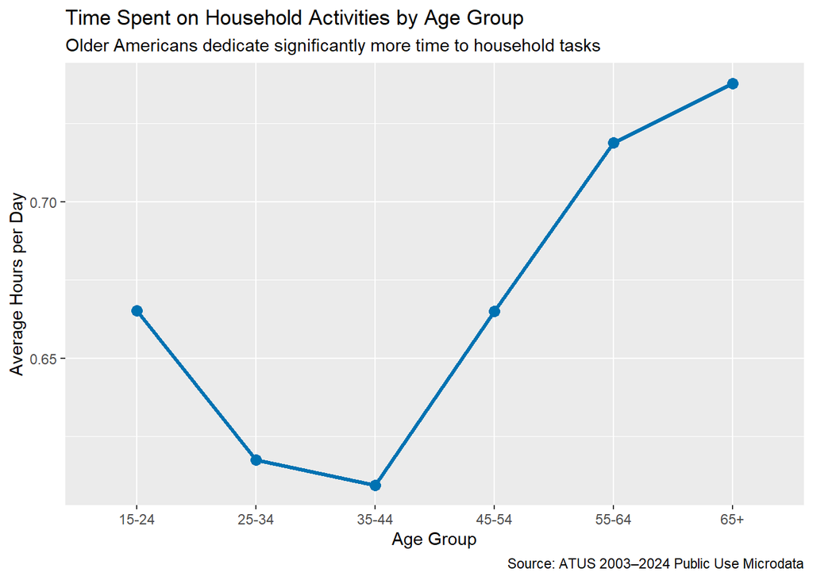

```r
household_by_age <- act_joined |>
    filter(str_detect(tolower(task_level1), "household")) |>
    filter(!is.na(age)) |>
    mutate(age_group = cut(age,
                           breaks = c(14, 24, 34, 44, 54, 64, 85),
                           labels = c("15-24", "25-34", "35-44",
                                      "45-54", "55-64", "65+"))) |>
    filter(!is.na(age_group)) |>
    group_by(age_group) |>
    summarize(
        avg_hrs = weighted.mean(time_spent_min, survey_weight, na.rm = TRUE) / 60,
        .groups = "drop"
    )

ggplot(household_by_age, aes(x = age_group, y = avg_hrs, group = 1)) +
    geom_line(color = "#0072B2", linewidth = 1.2) +
    geom_point(color = "#0072B2", size = 3) +
    labs(
        title    = "Time Spent on Household Activities by Age Group",
        subtitle = "Older Americans dedicate significantly more time to household tasks",
        x        = "Age Group",
        y        = "Average Hours per Day",
        caption  = "Source: ATUS 2003–2024 Public Use Microdata"
    )
```

#### Summer Activities for Education Workers

**View R Code**

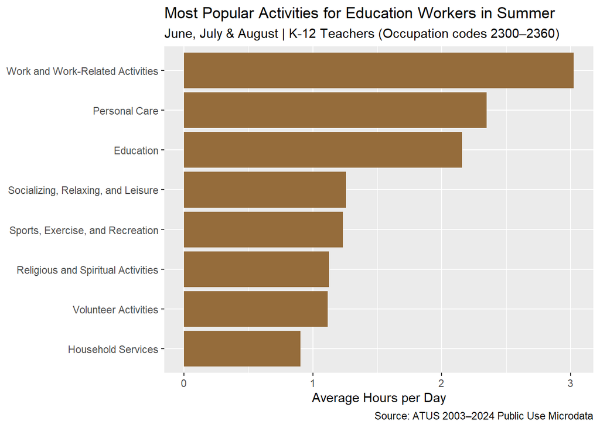

```r
summer_edu <- act_joined |>
    filter(!is.na(occupation)) |>
    filter(occupation >= 2300 & occupation <= 2360) |>
    filter(employment_status %in% c("Employed - Full Time",
                                     "Employed - Part Time")) |>
    filter(month %in% c(6, 7, 8)) |>
    filter(!str_detect(tolower(task_level1), "data code")) |>
    group_by(task_level1) |>
    summarize(
        avg_hrs = weighted.mean(time_spent_min, survey_weight, na.rm = TRUE) / 60,
        .groups = "drop"
    ) |>
    arrange(desc(avg_hrs)) |>
    slice_head(n = 8)

ggplot(summer_edu, aes(x = reorder(task_level1, avg_hrs), y = avg_hrs)) +
    geom_col(fill = "#956C3B") +
    coord_flip() +
    labs(
        title    = "Most Popular Activities for Education Workers in Summer",
        subtitle = "June, July & August | K-12 Teachers (Occupation codes 2300–2360)",
        x        = NULL,
        y        = "Average Hours per Day",
        caption  = "Source: ATUS 2003–2024 Public Use Microdata"
    )
```

#### Educational Activity Time Among College Students by Age

**View R Code**

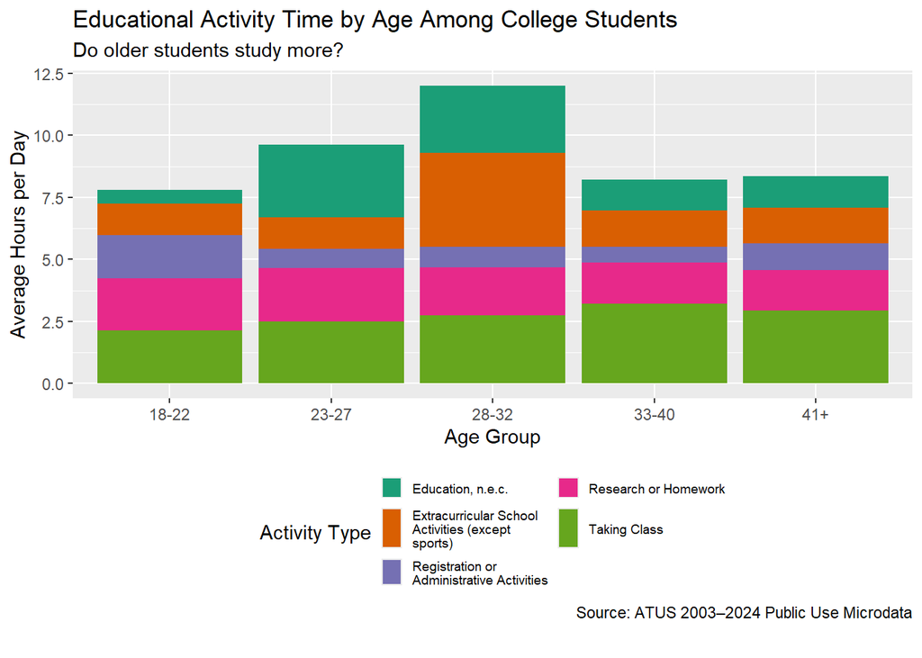

```r
college_edu <- act_joined |>
    filter(enrolled_in_college == TRUE) |>
    filter(str_detect(tolower(task_level1), "education")) |>
    filter(!is.na(age)) |>
    mutate(age_group = cut(age,
                           breaks = c(17, 22, 27, 32, 40, 85),
                           labels = c("18-22", "23-27", "28-32",
                                      "33-40", "41+"))) |>
    filter(!is.na(age_group)) |>
    group_by(age_group, task_level2) |>
    summarize(
        avg_hrs = weighted.mean(time_spent_min, survey_weight, na.rm = TRUE) / 60,
        .groups = "drop"
    )

ggplot(college_edu, aes(x = age_group, y = avg_hrs, fill = task_level2)) +
    geom_col(position = "stack") +
    scale_fill_brewer(type = "qual", palette = 2, name = "Activity Type",
                      labels = function(x) str_wrap(x, width = 25)) +
    labs(
        title    = "Educational Activity Time by Age Among College Students",
        subtitle = "Do older students study more?",
        x        = "Age Group",
        y        = "Average Hours per Day",
        caption  = "Source: ATUS 2003–2024 Public Use Microdata"
    ) +
    theme(
        legend.position  = "bottom",
        legend.text      = element_text(size = 7),
        legend.key.size  = unit(0.4, "cm"),
        plot.margin      = margin(5, 5, 20, 5)
    ) +
    guides(fill = guide_legend(nrow = 3))
```

#### Relative Popularity of Sports by Age Group

**View R Code**

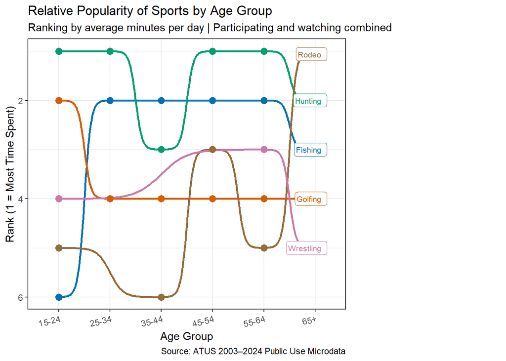

```r
sports_by_age <- act_joined |>
    filter(str_detect(tolower(task_level2), "sport")) |>
    filter(!str_detect(tolower(task_level3),
                       "^attending|^waiting|^travel|^security|^other|^extracurricular|vehicle touring")) |>
    filter(!is.na(age)) |>
    mutate(
        # Strip action prefix to group watching + participating together
        sport_name = str_remove(tolower(task_level3),
                                "^watching |^playing |^doing |^participating in "),
        # Clean up a few names for display
        sport_name = case_match(sport_name,
            "skiing, ice skating, snowboarding"  ~ "Skiing/Skating",
            "climbing, spelunking, caving"        ~ "Climbing/Caving",
            "weightlifting or strength training"  ~ "Weightlifting",
            "using cardiovascular equipment"      ~ "Cardio Equipment",
            "working out, unspecified"            ~ "Working Out",
            "people working out, unspecified"     ~ "Working Out",
            "rodeo competitions"                  ~ "Rodeo",
            "equestrian sports"                   ~ "Equestrian",
            "water sports"                        ~ "Water Sports",
            "racquet sports"                      ~ "Racquet Sports",
            "martial arts"                        ~ "Martial Arts",
            .default = str_to_title(sport_name)
        ),
        age_group = cut(age,
                        breaks = c(14, 24, 34, 44, 54, 64, 85),
                        labels = c("15-24", "25-34", "35-44",
                                   "45-54", "55-64", "65+"))
    ) |>
    filter(!is.na(age_group)) |>
    group_by(age_group, sport_name) |>
    summarize(
        avg_min = weighted.mean(time_spent_min, survey_weight, na.rm = TRUE),
        .groups = "drop"
    ) |>
    group_by(age_group) |>
    mutate(rank = rank(-avg_min, ties.method = "first")) |>
    filter(rank <= 6) |>
    ungroup() |>
    group_by(sport_name) |>
    filter(n() >= 3) |>
    ungroup()

# Safe, distinct color palette
safe_colors <- c("#0072B2", "#D55E00", "#009E73", "#956C3B",
                 "#CC79A7", "#8B0000", "#4B0082", "#2F4F4F",
                 "#556B2F", "#8B4513", "#483D8B", "#8B7355")

ggplot(sports_by_age, aes(x = age_group, y = rank,
                           color = sport_name, group = sport_name)) +
    geom_bump(linewidth = 1) +
    geom_point(size = 3) +
    geom_label_repel(
        data         = sports_by_age |> filter(age_group == "65+"),
        aes(label    = sport_name),
        hjust        = 0,
        nudge_x      = 0.5,
        size         = 2.8,
        direction    = "y",
        segment.size = 0.3,
        box.padding  = 0.6,
        force        = 8,
        fill         = "white",
        label.size   = 0.2
    ) +
    scale_y_reverse() +
    scale_color_manual(values = colorRampPalette(safe_colors)(12)) +
    coord_cartesian(clip = "off") +
    theme_bw() +
    theme(
        legend.position = "none",
        axis.text.x     = element_text(angle = 15, hjust = 1),
        plot.margin     = margin(5, 160, 5, 5)
    ) +
    labs(
        title    = "Relative Popularity of Sports by Age Group",
        subtitle = "Ranking by average minutes per day | Participating and watching combined",
        x        = "Age Group",
        y        = "Rank (1 = Most Time Spent)",
        caption  = "Source: ATUS 2003–2024 Public Use Microdata"
    )
```

#### Parental Care Time Per Child by Family Size

**View R Code**

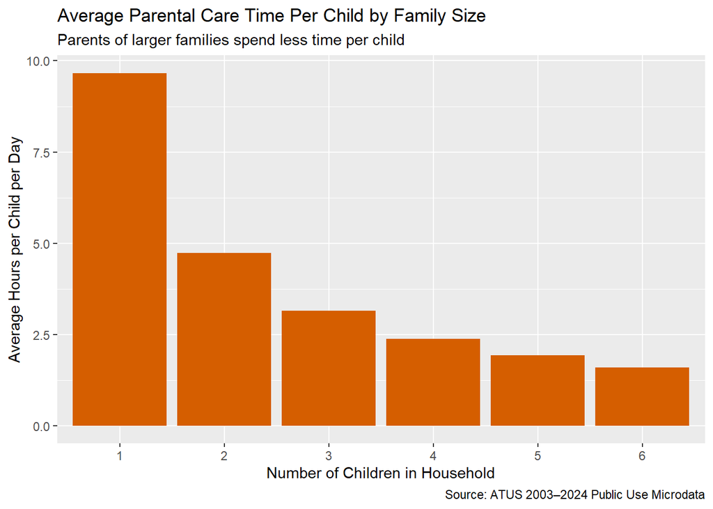

```r
childcare_per_child <- act_joined |>
    filter(str_detect(tolower(task_level1), "care")) |>
    filter(n_children >= 1) |>
    group_by(participant_id, n_children, survey_weight) |>
    summarize(
        total_cc_min = sum(time_spent_min, na.rm = TRUE),
        .groups = "drop"
    ) |>
    mutate(cc_per_child = total_cc_min / n_children) |>
    group_by(n_children) |>
    summarize(
        avg_hrs_per_child = weighted.mean(cc_per_child, survey_weight,
                                          na.rm = TRUE) / 60,
        .groups = "drop"
    ) |>
    filter(n_children <= 6)

ggplot(childcare_per_child, aes(x = factor(n_children), y = avg_hrs_per_child)) +
    geom_col(fill = "#D55E00") +
    labs(
        title    = "Average Parental Care Time Per Child by Family Size",
        subtitle = "Parents of larger families spend less time per child",
        x        = "Number of Children in Household",
        y        = "Average Hours per Child per Day",
        caption  = "Source: ATUS 2003–2024 Public Use Microdata"
    )
```

## Final Insights and Deliverable

### Time-Use Profiles for Target Demographics

**View R Code**

```r
# ── Demographic 1: Stay-at-home dads ─────────────────────────────────────────
# Definition: Male, married, not employed, at least 1 child under 18
sahd <- atus_resp |>
    filter(
        sex == "M",
        married == TRUE,
        n_children >= 1,
        employment_status %in% c("Not Employed - Not Looking",
                                  "Not Employed - Looking")
    )

sahd_key <- atus_act |>
    inner_join(atus_codes, join_by(level3_code == code_level3)) |>
    inner_join(sahd |> select(participant_id, survey_weight),
               join_by(participant_id)) |>
    filter(str_detect(tolower(task_level1),
                      "care|household|leisure")) |>
    mutate(activity = case_when(
        str_detect(tolower(task_level1), "care")      ~ "Child Care",
        str_detect(tolower(task_level1), "household") ~ "Household Activities",
        str_detect(tolower(task_level1), "leisure")   ~ "Leisure & Recreation"
    )) |>
    group_by(participant_id, activity, survey_weight) |>
    summarize(total_min = sum(time_spent_min, na.rm = TRUE), .groups = "drop") |>
    group_by(activity) |>
    summarize(
        low     = quantile(total_min, 0.25, na.rm = TRUE) / 60,
        avg_hrs = weighted.mean(total_min, survey_weight, na.rm = TRUE) / 60,
        high    = quantile(total_min, 0.75, na.rm = TRUE) / 60,
        .groups = "drop"
    ) |>
    mutate(
        target_hrs = case_when(
            activity == "Child Care"           ~ 6.0,
            activity == "Household Activities" ~ 3.0,
            activity == "Leisure & Recreation" ~ 2.0
        )
    )

# Compute % meeting target separately
sahd_pct <- atus_act |>
    inner_join(atus_codes, join_by(level3_code == code_level3)) |>
    inner_join(sahd |> select(participant_id, survey_weight),
               join_by(participant_id)) |>
    filter(str_detect(tolower(task_level1),
                      "care|household|leisure")) |>
    mutate(activity = case_when(
        str_detect(tolower(task_level1), "care")      ~ "Child Care",
        str_detect(tolower(task_level1), "household") ~ "Household Activities",
        str_detect(tolower(task_level1), "leisure")   ~ "Leisure & Recreation"
    )) |>
    group_by(participant_id, activity, survey_weight) |>
    summarize(total_hrs = sum(time_spent_min, na.rm = TRUE) / 60,
              .groups = "drop") |>
    mutate(target_hrs = case_when(
        activity == "Child Care"           ~ 6.0,
        activity == "Household Activities" ~ 3.0,
        activity == "Leisure & Recreation" ~ 2.0
    )) |>
    group_by(activity) |>
    summarize(
        pct_meeting_target = weighted.mean(total_hrs >= target_hrs,
                                           survey_weight, na.rm = TRUE),
        .groups = "drop"
    )

sahd_key |>
    left_join(sahd_pct, join_by(activity)) |>
    gt() |>
    cols_label(
        activity           = "Activity",
        low                = "Low (Q1 hrs)",
        avg_hrs            = "Typical (hrs/day)",
        high               = "High (Q3 hrs)",
        target_hrs         = "Target (hrs/day)",
        pct_meeting_target = "% Meeting Target"
    ) |>
    fmt_number(columns = c(low, avg_hrs, high, target_hrs), decimals = 1) |>
    fmt_percent(columns = pct_meeting_target, decimals = 0) |>
    tab_header(
        title    = "Time Use Profile: Stay-at-Home Dads",
        subtitle = "Married, unemployed men with at least one child under 18"
    ) |>
    tab_source_note("Source: ATUS 2003–2024 Public Use Microdata") |>
    tab_footnote(
        footnote = "Target levels represent suggested goals for the app's gamification system, based on product manager judgment.",
        locations = cells_column_labels(columns = target_hrs)
    )
```

Time Use Profile: Stay-at-Home Dads

Married, unemployed men with at least one child under 18

| Activity | Low (Q1 hrs) | Typical (hrs/day) | High (Q3 hrs) | Target (hrs/day)<sup>1</sup> | % Meeting Target |
| --- | --- | --- | --- | --- | --- |
| Child Care | 8.5 | 10.0 | 11.2 | 6.0 | 97% |
| Household Activities | 1.2 | 3.7 | 6.5 | 3.0 | 51% |
| Leisure & Recreation | 3.0 | 5.3 | 7.2 | 2.0 | 86% |

<sup>1</sup> Target levels represent suggested goals for the app's gamification system, based on product manager judgment.  
Source: ATUS 2003–2024 Public Use Microdata

**View R Code**

```r
# ── Demographic 2: College undergraduates ────────────────────────────────────
# Definition: Age 18-24, enrolled in college
college_students <- atus_resp |>
    filter(
        age >= 18 & age <= 24,
        enrolled_in_college == TRUE
    )

college_key <- atus_act |>
    inner_join(atus_codes, join_by(level3_code == code_level3)) |>
    inner_join(college_students |> select(participant_id, survey_weight),
               join_by(participant_id)) |>
    mutate(activity = case_when(
        str_detect(tolower(task_level1), "education")           ~ "Education & Studying",
        str_detect(tolower(task_level1), "personal")            ~ "Sleep & Personal Care",
        str_detect(tolower(task_level1), "leisure")             ~ "Leisure & Socializing",
        str_detect(tolower(task_level1), "work")                ~ "Working",
        TRUE ~ NA_character_
    )) |>
    filter(!is.na(activity)) |>
    group_by(participant_id, activity, survey_weight) |>
    summarize(total_min = sum(time_spent_min, na.rm = TRUE), .groups = "drop") |>
    group_by(activity) |>
    summarize(
        low     = quantile(total_min, 0.25, na.rm = TRUE) / 60,
        avg_hrs = weighted.mean(total_min, survey_weight, na.rm = TRUE) / 60,
        high    = quantile(total_min, 0.75, na.rm = TRUE) / 60,
        .groups = "drop"
    ) |>
    mutate(
        target_hrs = case_when(
            activity == "Education & Studying"  ~ 6.0,
            activity == "Sleep & Personal Care" ~ 8.0,
            activity == "Leisure & Socializing" ~ 3.0,
            activity == "Working"               ~ 2.0
        )
    )

# Compute % meeting target
college_pct <- atus_act |>
    inner_join(atus_codes, join_by(level3_code == code_level3)) |>
    inner_join(college_students |> select(participant_id, survey_weight),
               join_by(participant_id)) |>
    mutate(activity = case_when(
        str_detect(tolower(task_level1), "education")           ~ "Education & Studying",
        str_detect(tolower(task_level1), "personal")            ~ "Sleep & Personal Care",
        str_detect(tolower(task_level1), "leisure")             ~ "Leisure & Socializing",
        str_detect(tolower(task_level1), "work")                ~ "Working",
        TRUE ~ NA_character_
    )) |>
    filter(!is.na(activity)) |>
    group_by(participant_id, activity, survey_weight) |>
    summarize(total_hrs = sum(time_spent_min, na.rm = TRUE) / 60,
              .groups = "drop") |>
    mutate(target_hrs = case_when(
        activity == "Education & Studying"  ~ 6.0,
        activity == "Sleep & Personal Care" ~ 8.0,
        activity == "Leisure & Socializing" ~ 3.0,
        activity == "Working"               ~ 2.0
    )) |>
    group_by(activity) |>
    summarize(
        pct_meeting_target = weighted.mean(total_hrs >= target_hrs,
                                           survey_weight, na.rm = TRUE),
        .groups = "drop"
    )

college_key |>
    left_join(college_pct, join_by(activity)) |>
    gt() |>
    cols_label(
        activity           = "Activity",
        low                = "Low (Q1 hrs)",
        avg_hrs            = "Typical (hrs/day)",
        high               = "High (Q3 hrs)",
        target_hrs         = "Target (hrs/day)",
        pct_meeting_target = "% Meeting Target"
    ) |>
    fmt_number(columns = c(low, avg_hrs, high, target_hrs), decimals = 1) |>
    fmt_percent(columns = pct_meeting_target, decimals = 0) |>
    tab_header(
        title    = "Time Use Profile: College Undergraduates",
        subtitle = "Enrolled students ages 18–24"
    ) |>
    tab_source_note("Source: ATUS 2003–2024 Public Use Microdata") |>
    tab_footnote(
        footnote = "Target levels represent suggested goals for the app's gamification system, based on product manager judgment.",
        locations = cells_column_labels(columns = target_hrs)
    )
```

Time Use Profile: College Undergraduates

Enrolled students ages 18–24

| Activity | Low (Q1 hrs) | Typical (hrs/day) | High (Q3 hrs) | Target (hrs/day)<sup>1</sup> | % Meeting Target |
| --- | --- | --- | --- | --- | --- |
| Education & Studying | 2.2 | 5.5 | 7.0 | 6.0 | 41% |
| Leisure & Socializing | 2.0 | 4.1 | 6.2 | 3.0 | 58% |
| Sleep & Personal Care | 8.4 | 9.8 | 11.4 | 8.0 | 81% |
| Working | 4.5 | 6.2 | 8.5 | 2.0 | 89% |

<sup>1</sup> Target levels represent suggested goals for the app's gamification system, based on product manager judgment.  
Source: ATUS 2003–2024 Public Use Microdata

College undergraduates face a unique time allocation challenge: balancing academic demands with social life, work, and adequate rest. At 5.5 hours of education per day on average, students come close to but fall short of the 6-hour study target and only a fraction consistently hit that mark. The shortage in study time may be split among those students that prioritize social endeavors and those that need to work to support their tuition and living costs. In fact, working emerges as a surprising time commitment at 6.2 hours typical, far exceeding the 2-hour target and suggesting many students are balancing near-full-time work alongside their studies. Sleep and personal care average 9.8 hours, comfortably above the 8-hour target, while leisure at 4.1 hours exceeds the 3-hour target as well. The picture that emerges is of a demographic that is time-stretched in multiple directions, working more than is ideal for academic success while still finding time for social connection.

**View R Code**

```r
# ── Demographic 3: Career-Changing Graduate Students ─────────────────────────
career_changers <- atus_resp |>
    filter(
        age >= 30 & age <= 40,
        enrolled_in_college == TRUE,
        married == TRUE,
        n_children == 0,
        employment_status %in% c("Employed - Part Time",
                                  "Not Employed - Not Looking",
                                  "Not Employed - Looking")
    )

career_changer_key <- atus_act |>
    inner_join(atus_codes, join_by(level3_code == code_level3)) |>
    inner_join(career_changers |> select(participant_id, survey_weight),
               join_by(participant_id)) |>
    mutate(activity = case_when(
        str_detect(tolower(task_level1), "education")  ~ "Education & Studying",
        str_detect(tolower(task_level1), "work")       ~ "Working & Work-Related",
        str_detect(tolower(task_level1), "leisure")    ~ "Leisure & Recreation",
        str_detect(tolower(task_level1), "personal")   ~ "Sleep & Personal Care",
        str_detect(tolower(task_level1), "household")  ~ "Household Activities",
        TRUE ~ NA_character_
    )) |>
    filter(!is.na(activity)) |>
    group_by(participant_id, activity, survey_weight) |>
    summarize(total_min = sum(time_spent_min, na.rm = TRUE), .groups = "drop") |>
    group_by(activity) |>
    summarize(
        low     = quantile(total_min, 0.25, na.rm = TRUE) / 60,
        avg_hrs = weighted.mean(total_min, survey_weight, na.rm = TRUE) / 60,
        high    = quantile(total_min, 0.75, na.rm = TRUE) / 60,
        .groups = "drop"
    ) |>
    mutate(
        target_hrs = case_when(
            activity == "Education & Studying"   ~ 6.0,
            activity == "Working & Work-Related" ~ 2.0,
            activity == "Leisure & Recreation"   ~ 2.5,
            activity == "Sleep & Personal Care"  ~ 8.0,
            activity == "Household Activities"   ~ 1.5
        )
    )

# Compute % meeting target
career_pct <- atus_act |>
    inner_join(atus_codes, join_by(level3_code == code_level3)) |>
    inner_join(career_changers |> select(participant_id, survey_weight),
               join_by(participant_id)) |>
    mutate(activity = case_when(
        str_detect(tolower(task_level1), "education")  ~ "Education & Studying",
        str_detect(tolower(task_level1), "work")       ~ "Working & Work-Related",
        str_detect(tolower(task_level1), "leisure")    ~ "Leisure & Recreation",
        str_detect(tolower(task_level1), "personal")   ~ "Sleep & Personal Care",
        str_detect(tolower(task_level1), "household")  ~ "Household Activities",
        TRUE ~ NA_character_
    )) |>
    filter(!is.na(activity)) |>
    group_by(participant_id, activity, survey_weight) |>
    summarize(total_hrs = sum(time_spent_min, na.rm = TRUE) / 60,
              .groups = "drop") |>
    mutate(target_hrs = case_when(
        activity == "Education & Studying"   ~ 6.0,
        activity == "Working & Work-Related" ~ 2.0,
        activity == "Leisure & Recreation"   ~ 2.5,
        activity == "Sleep & Personal Care"  ~ 8.0,
        activity == "Household Activities"   ~ 1.5
    )) |>
    group_by(activity) |>
    summarize(
        pct_meeting_target = weighted.mean(total_hrs >= target_hrs,
                                           survey_weight, na.rm = TRUE),
        .groups = "drop"
    )

career_changer_key |>
    left_join(career_pct, join_by(activity)) |>
    gt() |>
    cols_label(
        activity           = "Activity",
        low                = "Low (Q1 hrs)",
        avg_hrs            = "Typical (hrs/day)",
        high               = "High (Q3 hrs)",
        target_hrs         = "Target (hrs/day)",
        pct_meeting_target = "% Meeting Target"
    ) |>
    fmt_number(columns = c(low, avg_hrs, high, target_hrs), decimals = 1) |>
    fmt_percent(columns = pct_meeting_target, decimals = 0) |>
    tab_header(
        title    = "Time Use Profile: Career-Changing Graduate Students",
        subtitle = "Married adults ages 30–40, enrolled in college, no children, working part-time or not at all"
    ) |>
    tab_source_note("Source: ATUS 2003–2024 Public Use Microdata") |>
    tab_footnote(
        footnote = "Target levels represent suggested goals for the app's gamification system, based on product manager judgment.",
        locations = cells_column_labels(columns = target_hrs)
    )
```

Time Use Profile: Career-Changing Graduate Students

Married adults ages 30–40, enrolled in college, no children, working part-time or not at all

| Activity | Low (Q1 hrs) | Typical (hrs/day) | High (Q3 hrs) | Target (hrs/day)<sup>1</sup> | % Meeting Target |
| --- | --- | --- | --- | --- | --- |
| Education & Studying | 1.4 | 3.8 | 4.5 | 6.0 | 29% |
| Household Activities | 0.8 | 2.1 | 2.7 | 1.5 | 64% |
| Leisure & Recreation | 3.0 | 4.1 | 5.6 | 2.5 | 72% |
| Sleep & Personal Care | 8.9 | 10.0 | 11.6 | 8.0 | 86% |
| Working & Work-Related | 0.8 | 3.3 | 2.5 | 2.0 | 72% |

<sup>1</sup> Target levels represent suggested goals for the app's gamification system, based on product manager judgment.  
Source: ATUS 2003–2024 Public Use Microdata

Career-changing graduate students occupy a uniquely demanding position: unlike traditional students, they bring years of professional experience into the classroom while simultaneously managing the responsibilities of adult life. At 3.8 hours of education per day on average, this group studies significantly less than traditional undergraduates at 5.5 hours. This gap likely reflects the competing demands of part-time work, household responsibilities, and the general pace of adult life. Leisure at 4.1 hours exceeds the 2.5-hour target, suggesting that while career changers are stretched, they are not sacrificing personal time entirely. Sleep and personal care at 10 hours is above the 8-hour target, which is a positive sign for well-being. The most actionable insight for the app is the study time gap. Nudging this demographic toward the 6-hour target represents the clearest opportunity for “gamification” to make a meaningful difference in academic outcomes.

**View R Code**

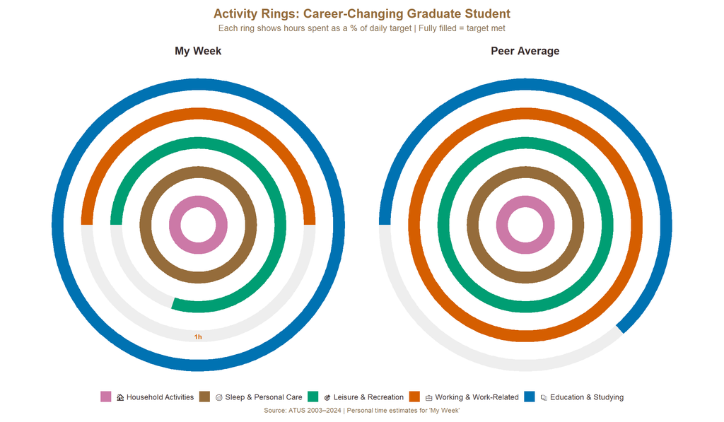

```r
# ── Data setup ────────────────────────────────────────────────────────────────
activities <- c("Education &\nStudying", "Working &\nWork-Related",
                "Leisure &\nRecreation", "Sleep &\nPersonal Care",
                "Household\nActivities")

target_hrs  <- c(6.0, 2.0, 2.5, 8.0, 1.5)
typical_hrs <- c(3.8, 3.3, 4.1, 10.0, 2.1)
my_hrs      <- c(8.0, 1.0, 2.0, 8.0, 3.0)

target_pct_typical <- pmin(typical_hrs / target_hrs, 1)
target_pct_mine    <- pmin(my_hrs / target_hrs, 1)

n <- length(activities)

rings_data <- data.frame(
    activity   = rep(factor(activities, levels = rev(activities)), 2),
    group      = rep(c("Peer Average", "My Week"), each = n),
    pct        = c(target_pct_typical, target_pct_mine),
    actual_hrs = c(typical_hrs, my_hrs),
    target_hrs = rep(target_hrs, 2),
    ring       = rep(seq(n, 1), 2)
)

ring_colors <- c(
    "Education &\nStudying"   = "#0072B2",
    "Working &\nWork-Related" = "#D55E00",
    "Leisure &\nRecreation"   = "#009E73",
    "Sleep &\nPersonal Care"  = "#956C3B",
    "Household\nActivities"   = "#CC79A7"
)

# Label data — place at end of each arc
label_data <- rings_data |>
    mutate(
        angle     = 2 * pi * pct - pi/2,
        label_x   = (ring - 0.2) * cos(angle),
        label_y   = (ring - 0.2) * sin(angle),
        short_label = case_when(
            grepl("Education", activity)  ~ "📚",
            grepl("Working",   activity)  ~ "💼",
            grepl("Leisure",   activity)  ~ "🎯",
            grepl("Sleep",     activity)  ~ "😴",
            grepl("Household", activity)  ~ "🏠"
        ),
        hours_label = paste0(actual_hrs, "h")
    )

# Legend data
legend_data <- data.frame(
    activity  = factor(activities, levels = rev(activities)),
    color     = unname(ring_colors[activities]),
    emoji     = c("📚", "💼", "🎯", "😴", "🏠"),
    target    = target_hrs,
    ring      = seq(n, 1)
)

ggplot(rings_data) +
    # Background track
    geom_arc_bar(
        aes(x0 = 0, y0 = 0, r0 = ring - 0.4, r = ring,
            start = 0, end = 2 * pi),
        fill = "#EEEEEE", color = NA
    ) +
    # Filled arcs
    geom_arc_bar(
        aes(x0 = 0, y0 = 0, r0 = ring - 0.4, r = ring,
            start = -pi/2, end = -pi/2 + 2 * pi * pct,
            fill = activity),
        color = NA
    ) +
    # Hours label at center-right of each ring
    geom_text(
        data = rings_data |> filter(group == "My Week"),
        aes(x = 0, y = -ring + 0.2,
            label = paste0(actual_hrs, "h"),
            color = activity),
        size = 2.8, fontface = "bold", hjust = 0.5
    ) +
    scale_fill_manual(
        values = ring_colors,
        name   = NULL,
        labels = c(
            "Education &\nStudying"   = "📚 Education & Studying",
            "Working &\nWork-Related" = "💼 Working & Work-Related",
            "Leisure &\nRecreation"   = "🎯 Leisure & Recreation",
            "Sleep &\nPersonal Care"  = "😴 Sleep & Personal Care",
            "Household\nActivities"   = "🏠 Household Activities"
        )
    ) +
    scale_color_manual(values = ring_colors, guide = "none") +
    coord_equal(clip = "off") +
    facet_wrap(~group) +
    theme_void() +
    theme(
        strip.text      = element_text(size = 13, face = "bold",
                                       color = "#3B2F2F", margin = margin(b = 10)),
        plot.title      = element_text(size = 15, face = "bold",
                                       color = "#956C3B", hjust = 0.5,
                                       margin = margin(b = 5)),
        plot.subtitle   = element_text(size = 10, color = "#8B7355",
                                       hjust = 0.5, margin = margin(b = 15)),
        plot.caption    = element_text(size = 8, color = "#8B7355", hjust = 0.5),
        plot.margin     = margin(10, 10, 10, 10),
        legend.position = "bottom",
        legend.text     = element_text(size = 9, color = "#3B2F2F"),
        legend.key.size = unit(0.5, "cm"),
        legend.spacing.x = unit(0.8, "cm")
    ) +
    guides(fill = guide_legend(nrow = 1)) +
    labs(
        title    = "Activity Rings: Career-Changing Graduate Student",
        subtitle = "Each ring shows hours spent as a % of daily target | Fully filled = target met",
        caption  = "Source: ATUS 2003–2024 | Personal time estimates for 'My Week'"
    )
```

## Conclusion

This analysis, of over two decades of ATUS microdata, reveals several interesting patterns in how Americans allocate their time. Older Americans spend significantly more hours doing household tasks, while younger Americans, particularly college students, spend surprisingly, or maybe not, little time on academic pursuits relative to the recommended benchmarks. The results also highlight that parental attention is clearly a finite resource, with time per child declining sharply as family size grows, lending empirical support to the concept of “middle-child syndrome.”

For the time-tracking app, our three target demographics: stay-at-home dads, college undergraduates, and career-changing graduate students, each present distinct time-use patterns and distinct gaps between typical and target behavior. These gaps represent the core opportunity for “gamification”: nudging users toward healthier time allocation by showing them how they compare to peers and to evidence-based targets.

Future analyses could incorporate longitudinal tracking to understand how individual time-use evolves over life stages, or integrate well-being survey data to identify which time allocations are most strongly associated with reported happiness and life satisfaction.

**NoteAI Usage Statement**

Claude (Anthropic) was used in this mini-project to assist with R code generation, debugging, and structuring the analytical pipeline. Specifically, AI assistance was used to help write and troubleshoot the data loading functions, join logic between ATUS files, and ggplot2 visualization code. All written narrative text, including the introduction, interpretive paragraphs, and conclusion, was written by the student without AI assistance, in accordance with course policy. AI was not used to write or edit any non-code text in this report.

This work ©2026 by Git User: raulsolanavarro was initially prepared as a Mini-Project for STA 9750 at Baruch College. More details about this course can be found at [the course site](https://michael-weylandt.com/STA9750) and instructions for this assignment can be found at [MP #02](https://michael-weylandt.com/STA9750/mini/mini02.html)